# Explanatory slides

Percenatge of bikes used in San fransicso in day to day life.

Investigation Overview In this investigation, I wanted to look at the age group who are using bikes that could be used to analyze bikes used

Dataset Overview The data consists of information regarding 519701 bike rides in san francisco start_time ,end_time start_station_name ,end_station_name,start and end station longitude and latitude,bike_id,member and gender

Age group given dataframe is plotted to see the range of ages.

Age Group we are plotting age groups who are using bikes

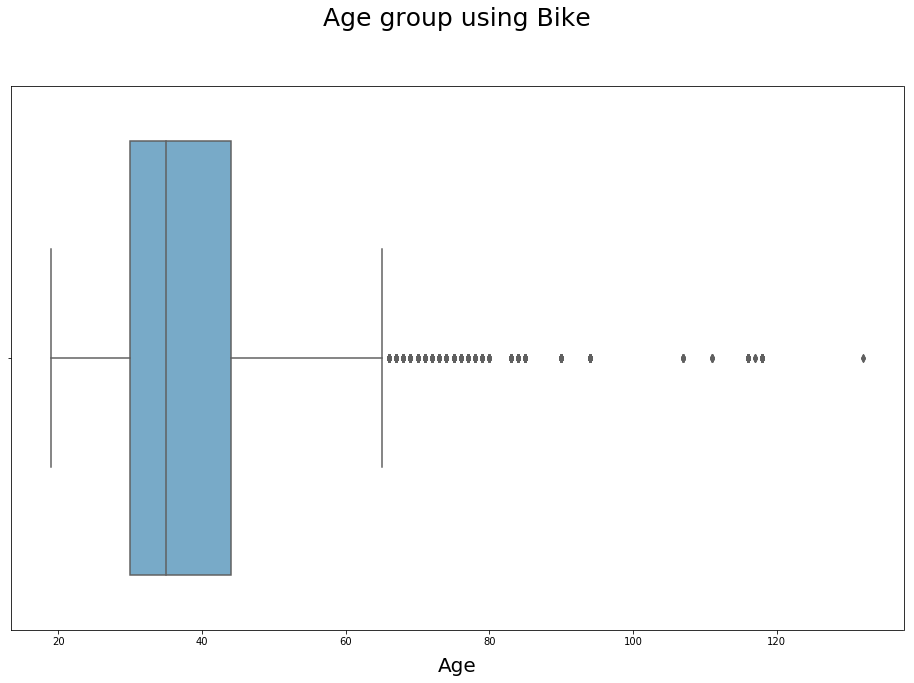

```python
#plotting which ages are using bikes
plt.figure(figsize=(16,10))
sns.boxplot(x='member_age', data=df, palette='Blues', orient='h')
plt.title("Age group using Bike", fontsize=25, y=1.1)
plt.xlabel("Age", fontsize=20, labelpad=10)
plt.show()
```

From the above plot Age group given dataframe is plotted to see the range of ages.From above we can see 30 to 45 ages are using bike.

Age groups in different month of a year Plotting which age groups are riding bikes more in which month of the year.

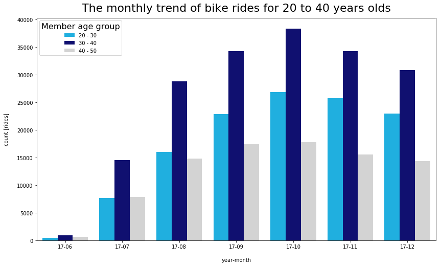

```python
#Plotting age groups in which month having more rides
plt.figure(figsize=(14,8))
my_palette = {'20 - 30': 'deepskyblue', '30 - 40': 'navy', '40 - 50': 'lightgrey'}
graph = sns.countplot(x='start_time_year_month_renamed', hue='member_age_groups', palette=my_palette, data=df[df['member_age_groups'].isin(['20 - 30', '30 - 40', '40 - 50'])].sort_values(by=['start_time_year_month_renamed', 'member_age_groups']))
plt.title('The monthly trend of bike rides for 20 to 40 years olds', fontsize=22, y=1.015)
plt.xlabel('year-month', labelpad=16)
plt.ylabel('count [rides]', labelpad=16)
leg = graph.legend()
leg.set_title('Member age group',prop={'size':16})
graph = plt.gca();
plt.show()
```

Month vs age : In October month people between 30 to 40 age riding bike more Compared to other month in an year and age group between 30 to 40 are Using the bike more.

Monthly trends Plotting which month is having more bike rides compared to others.From that we can see which month if the year is having more bike rides.

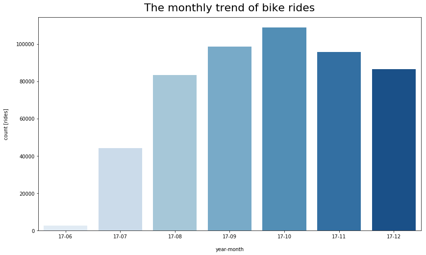

```python
#number of rides per month
plt.figure(figsize=(14,8))
sns.countplot(x='start_time_year_month_renamed', palette="Blues", data=df.sort_values(by='start_time_year_month_renamed'))
plt.title('The monthly trend of bike rides', fontsize=22, y=1.015)
plt.xlabel('year-month', labelpad=16)
plt.ylabel('count [rides]', labelpad=16)
ax = plt.gca()
```

Bike ride from june to decemeber In the month of october the overall count of bike rides is more.

Age versus number of rides Plotting which age group is using more bike.

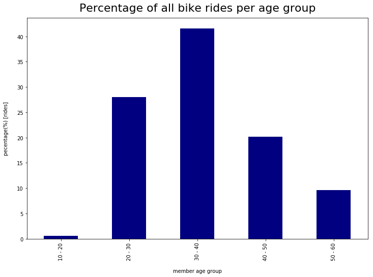

```python
#plotting age versus percentage of riders
ridebyage['percentage'].plot('bar', color='navy',figsize=(12,8))
plt.title('Percentage of all bike rides per age group', fontsize=22, y=1.015)
plt.xlabel('member age group', labelpad=16)
plt.ylabel('pecentage(%) [rides]', labelpad=16)
plt.show()
```

Bike ride percentage versus age group The percentage the bike ride is the number of bike rides versus the age group More percentage of bike are used by 30 -40 age group.

Gender versus percentage of bike rides Plotting which gender are using more bike.

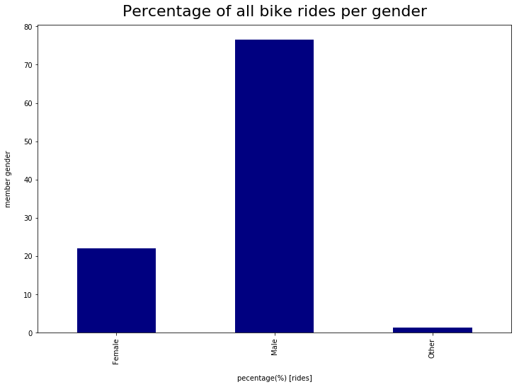

```python
#Plotting gender versus pecentage
gendergroup['percentage'].plot('bar',figsize=(12,8),color='navy')
plt.title('Percentage of all bike rides per gender', fontsize=22, y=1.015)
plt.ylabel('member gender', labelpad=16)
plt.xlabel('pecentage(%) [rides]', labelpad=16)
plt.show()
```

Gender vs Bike rides

Male and female tells number of male and female using bikes.Male ride more Bikes than female.

# Bike rides in a weekday

Number of bike rides in a weekday,which day of the week is having more bike rides

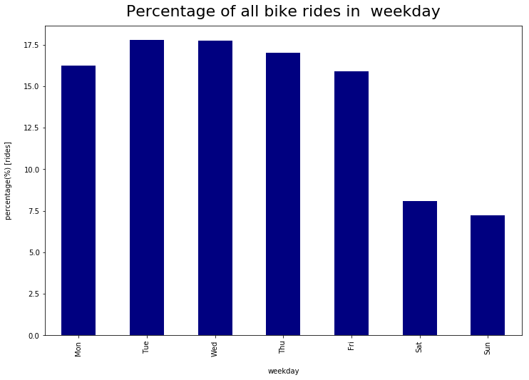

```python
#Percentage of all bike rides in weekday
tripin_weekday.reindex(weekday)['percentage'].plot('bar',figsize=(12,8),color='navy')
plt.title('Percentage of all bike rides in  weekday', fontsize=22, y=1.015)
plt.xlabel('weekday', labelpad=16)
plt.ylabel('percentage(%) [rides]', labelpad=16)
plt.show()
```

Bike ride versus weekday Percentage of bike ride on the weekdays which tells us which day bike rides are More.From the plot it says Tuesday and Wednesday bikes are used more

Peak hours of a day Plotting which are the peak hours of bike rides in a day

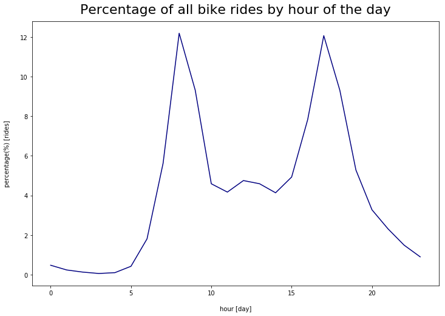

```python
#Percentage of all bike rides by hour of the day
rides_per_day['bike_id'].plot('line',figsize=(12,8),color='navy')
plt.title('Percentage of all bike rides by hour of the day', fontsize=22, y=1.015)
plt.xlabel('hour [day]', labelpad=16)
plt.ylabel('percentage(%) [rides]', labelpad=16)
plt.show()
```

Bike ride versus peak hours Bike ride are used more from 8 A.M in the morning and 5 P.M in the evening

Monthly trend of bike ride per user type Plotting which user type is having more bike rides in an year from june to december

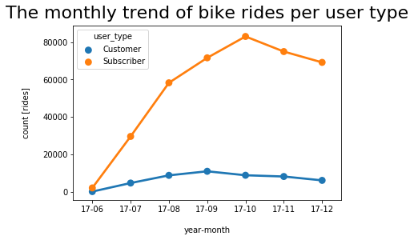

```python
#Plotting usertype with bike rides
sns.pointplot(x='start_time_year_month_renamed', y=0, hue='user_type',data=user_type_number)
plt.title('The monthly trend of bike rides per user type', fontsize=22, y=1.015)
plt.xlabel('year-month', labelpad=16)
plt.ylabel('count [rides]', labelpad=16)
plt.show()
```

User_type versus year User_type is customer and subcribers.Subcribers ride bike more than customers Subcribers are who subscribed and cutomers are who takes when needed.

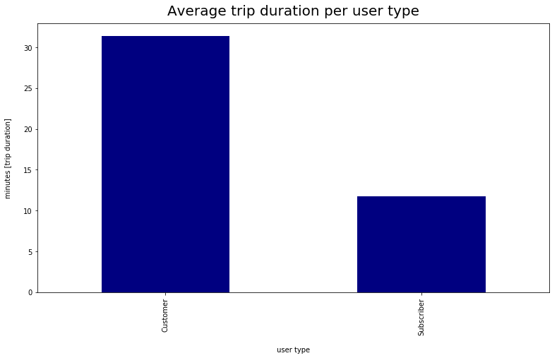

```python
#grouping usser_type with duration
df['duration_min'] = df['duration_sec']/60
user_duration = df.groupby('user_type')['duration_min'].mean().plot(kind='bar', color='navy', figsize=(13,7))
user_duration.set_title('Average trip duration per user type', fontsize=20, y=1.015)
user_duration.set_xlabel('user type', labelpad=16)
user_duration.set_ylabel('minutes [trip duration]', labelpad=16)
plt.show()
```

Monthly trends of bike per subscriber member age group Plotting monthly trend of bike rides per subscriber with respect to age group

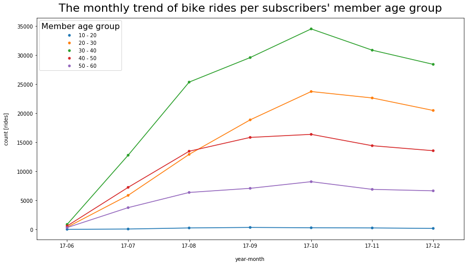

```python
#Monthly bike rides per subscriber member age group
plt.figure(figsize=(15,8))
graph=sns.pointplot(x='start_time_year_month_renamed', y='bike_id', hue='member_age_groups', scale=.6, data=subscriber_age)
plt.title("The monthly trend of bike rides per subscribers' member age group", fontsize=22, y=1.015)
plt.xlabel('year-month', labelpad=16)
plt.ylabel('count [rides]', labelpad=16)
leg = graph.legend()
leg.set_title('Member age group',prop={'size':16})
```

Age group versus year-month Which age group ride bike more and in which month/year.30 to 40 age group Rides bike more in the month of October 2017.